# TÜİK Construction Cost Index (2015=100) — Forecasting Project

Nazlı Pirim

2026-06-03

# 1 Project Overview

This project forecasts the TÜİK Construction Cost Index (2015=100) using monthly data accessed directly from the TÜİK Data Portal via the `tuikr` R package. The forecast target is **February 2026**, the next period after the latest available observation of January 2026.

# 2 Data Source Information

- **TÜİK Dataset:** Construction Cost Index (2015=100) and Rate of Change
- **Theme:** Price Statistics (Theme 6)
- **Node Type:** istab
- **Selected Variable:** Construction Cost Index (2015=100)
- **Frequency:** Monthly
- **Coverage:** 2015-01 to 2026-01
- **Latest Observation:** January 2026
- **Forecast Target:** February 2026
- **Data Access Date:** 2026-06-03
- **Package:** tuikr — https://github.com/emraher/tuikr

# 3 Data Access via tuikr

```r
library(tuikr)
library(httr)
library(readxl)
library(tidyverse)
library(lubridate)
library(forecast)
library(zoo)
library(TTR)
library(knitr)
library(kableExtra)

# Klasörleri oluştur
dir.create("outputs/tables",  recursive = TRUE, showWarnings = FALSE)
dir.create("outputs/figures", recursive = TRUE, showWarnings = FALSE)

# TÜİK Theme 6 tablolarını çek
tables <- statistical_tables(theme = 6)

# Construction Cost Index URL'sini al
cci_url <- tables$table_url[
  grepl("Construction Cost Index.*2015.*Rate", tables$table_name, ignore.case = TRUE)
][1]

cat("Dataflow URL alındı.\n")
```

```
## Dataflow URL alındı.
```

```r
cat("Veri erişim tarihi:", as.character(Sys.Date()), "\n")
```

```
## Veri erişim tarihi: 2026-06-03
```

```r
# Veriyi tarayıcı başlıklarıyla çek
response <- GET(
  cci_url,
  add_headers(
    "User-Agent" = "Mozilla/5.0 (Windows NT 10.0; Win64; x64) AppleWebKit/537.36",
    "Referer"    = "https://veriportali.tuik.gov.tr/",
    "Accept"     = "application/vnd.openxmlformats-officedocument.spreadsheetml.sheet"
  ),
  write_disk("cci_raw.xls", overwrite = TRUE)
)

cat("HTTP Status:", status_code(response), "\n")
```

```
## HTTP Status: 200
```

# 4 Data Preparation

```r
# Ham veriyi oku
df_raw <- read_xls("cci_raw.xls", col_names = FALSE)

# Endeks satırlarını al (2015-2026)
row_2015 <- which(df_raw[[1]] == "2015")[1]
row_2026 <- which(df_raw[[1]] == "2026")[1]

df_index <- df_raw[row_2015:row_2026, 1:13]
colnames(df_index) <- c("year","Jan","Feb","Mar","Apr","May","Jun",
                         "Jul","Aug","Sep","Oct","Nov","Dec")

# Long formata çevir
df_long <- df_index %>%
  mutate(year = as.integer(year)) %>%
  pivot_longer(cols = Jan:Dec, names_to = "month", values_to = "cci") %>%
  mutate(
    month_num = match(month, c("Jan","Feb","Mar","Apr","May","Jun",
                                "Jul","Aug","Sep","Oct","Nov","Dec")),
    period    = ym(paste(year, month_num, sep = "-")),
    cci       = as.numeric(cci)
  ) %>%
  filter(!is.na(cci)) %>%
  arrange(period) %>%
  select(period, cci)

cat("Toplam gözlem    :", nrow(df_long), "\n")
```

```
## Toplam gözlem    : 133
```

```r
cat("İlk dönem        :", format(min(df_long$period), "%Y-%m"), "\n")
```

```
## İlk dönem        : 2015-01
```

```r
cat("Son dönem        :", format(max(df_long$period), "%Y-%m"), "\n")
```

```
## Son dönem        : 2026-01
```

```r
cat("Eksik değer      :", sum(is.na(df_long$cci)), "\n")
```

```
## Eksik değer      : 0
```

```r
tail(df_long, 6)
```

```
## # A tibble: 6 × 2
##   period       cci
##   <date>     <dbl>
## 1 2025-08-01 1930.
## 2 2025-09-01 1947.
## 3 2025-10-01 1966.
## 4 2025-11-01 1989.
## 5 2025-12-01 2012.
## 6 2026-01-01 2210.
```

# 5 Exploratory Analysis

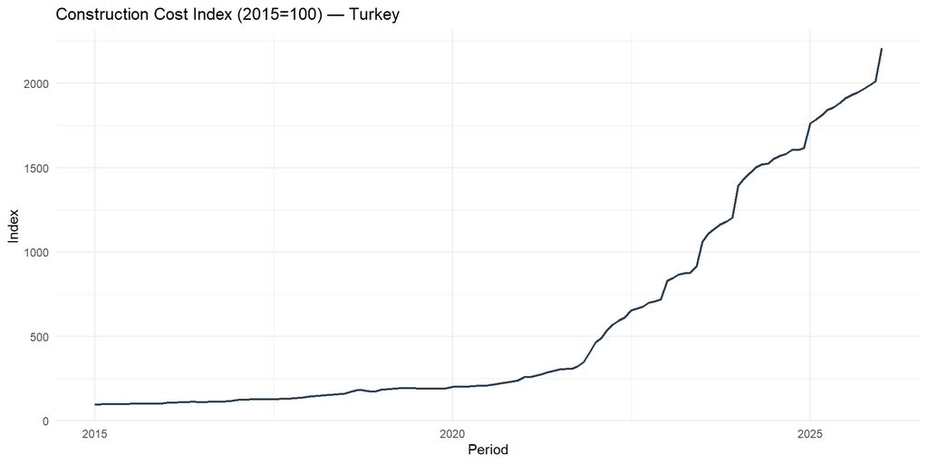

```r
# Zaman serisi nesnesi
ts_cci <- ts(df_long$cci,
             start     = c(year(min(df_long$period)), month(min(df_long$period))),
             frequency = 12)

# Gerçek seri grafiği
p_actual <- ggplot(df_long, aes(x = period, y = cci)) +
  geom_line(color = "#2C3E50", linewidth = 0.8) +
  labs(title = "Construction Cost Index (2015=100) — Turkey",
       x = "Period", y = "Index") +
  theme_minimal()
print(p_actual)
```

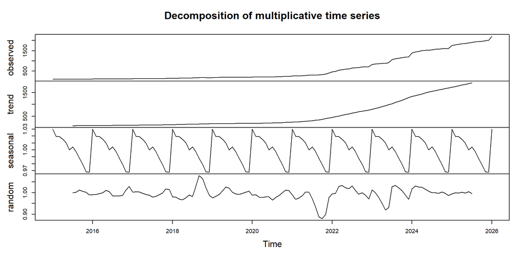

```r
ggsave("outputs/figures/actual_series_plot.png", p_actual, width = 10, height = 5)

# Decomposition
decomp <- decompose(ts_cci, type = "multiplicative")
plot(decomp)
```

# 6 Accuracy Function

```r
calc_accuracy <- function(actual, forecast) {
  errors <- actual - forecast
  n      <- length(errors)
  bias   <- mean(errors,       na.rm = TRUE)
  mad    <- mean(abs(errors),  na.rm = TRUE)
  mse    <- mean(errors^2,     na.rm = TRUE)
  mape   <- mean(abs(errors / actual) * 100, na.rm = TRUE)
  rsfe   <- sum(errors,        na.rm = TRUE)
  ts_val <- rsfe / mad
  list(Bias=round(bias,2), MAD=round(mad,2), MSE=round(mse,2),
       MAPE=round(mape,2), RSFE=round(rsfe,2), TS=round(ts_val,2))
}
```

# 7 Forecasting Methods

## 7.1 Naïve

```r
naive_fc  <- c(NA, head(df_long$cci, -1))
naive_acc <- calc_accuracy(df_long$cci[-1], naive_fc[-1])
naive_next <- tail(df_long$cci, 1)
cat("Naïve Feb 2026 forecast:", naive_next, "\n")
```

```
## Naïve Feb 2026 forecast: 2210.24
```

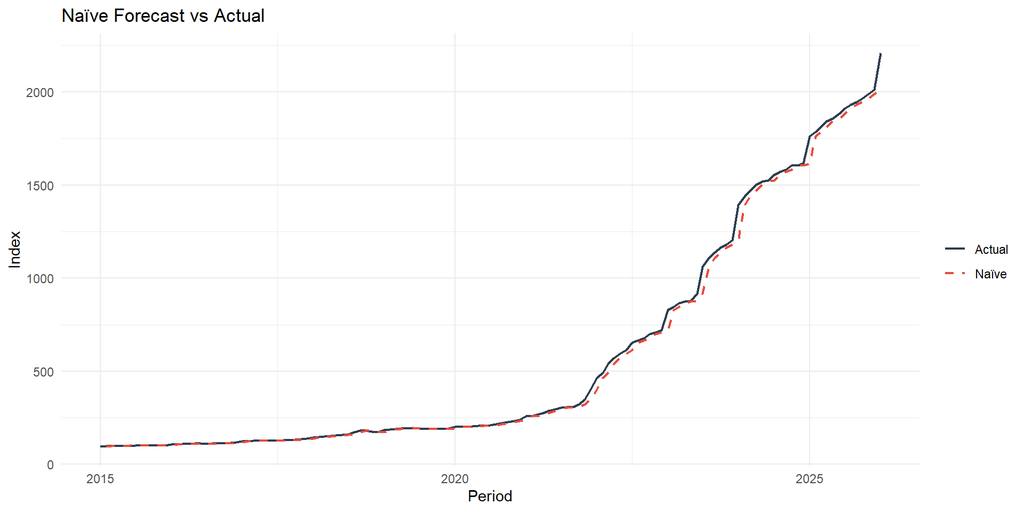

```r
p_naive <- ggplot(df_long, aes(x=period)) +
  geom_line(aes(y=cci,       color="Actual"),  linewidth=0.8) +
  geom_line(aes(y=naive_fc,  color="Naïve"),   linewidth=0.8, linetype="dashed") +
  scale_color_manual(values=c("Actual"="#2C3E50","Naïve"="#E74C3C")) +
  labs(title="Naïve Forecast vs Actual", x="Period", y="Index", color="") +
  theme_minimal()
print(p_naive)
```

```r
ggsave("outputs/figures/naive_forecast_plot.png", p_naive, width=10, height=5)
```

## 7.2 Moving Average

```r
ma3 <- rollmean(df_long$cci, k=3, fill=NA, align="right")
ma_fc  <- c(NA, head(ma3, -1))
valid  <- !is.na(ma_fc)
ma_acc <- calc_accuracy(df_long$cci[valid], ma_fc[valid])
ma_next <- mean(tail(df_long$cci, 3))
cat("MA(3) Feb 2026 forecast:", ma_next, "\n")
```

```
## MA(3) Feb 2026 forecast: 2070.19
```

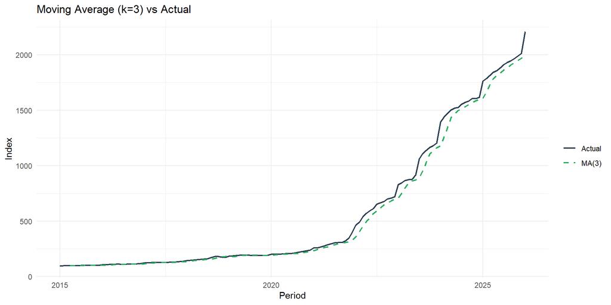

```r
p_ma <- ggplot(df_long, aes(x=period)) +
  geom_line(aes(y=cci,   color="Actual"), linewidth=0.8) +
  geom_line(aes(y=ma_fc, color="MA(3)"), linewidth=0.8, linetype="dashed") +
  scale_color_manual(values=c("Actual"="#2C3E50","MA(3)"="#27AE60")) +
  labs(title="Moving Average (k=3) vs Actual", x="Period", y="Index", color="") +
  theme_minimal()
print(p_ma)
```

```r
ggsave("outputs/figures/moving_average_plot.png", p_ma, width=10, height=5)
```

## 7.3 Weighted Moving Average

```r
w <- c(1/6, 2/6, 3/6)
n <- nrow(df_long)
wma_fc <- rep(NA, n)
for(i in 4:n) wma_fc[i] <- sum(w * df_long$cci[(i-3):(i-1)])
valid_w  <- !is.na(wma_fc)
wma_acc  <- calc_accuracy(df_long$cci[valid_w], wma_fc[valid_w])
wma_next <- sum(w * tail(df_long$cci, 3))
cat("WMA Feb 2026 forecast:", wma_next, "\n")
```

```
## WMA Feb 2026 forecast: 2107.135
```

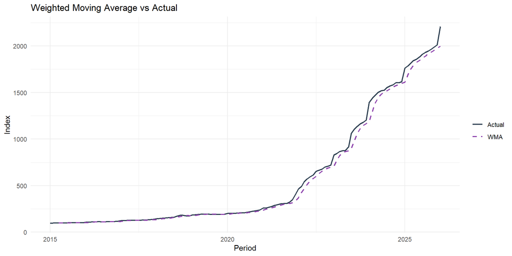

```r
p_wma <- ggplot(df_long %>% mutate(wma=wma_fc), aes(x=period)) +
  geom_line(aes(y=cci, color="Actual"), linewidth=0.8) +
  geom_line(aes(y=wma, color="WMA"),   linewidth=0.8, linetype="dashed") +
  scale_color_manual(values=c("Actual"="#2C3E50","WMA"="#8E44AD")) +
  labs(title="Weighted Moving Average vs Actual", x="Period", y="Index", color="") +
  theme_minimal()
print(p_wma)
```

```r
ggsave("outputs/figures/weighted_moving_average_plot.png", p_wma, width=10, height=5)
```

## 7.4 Exponential Smoothing

```r
es_model  <- ses(ts_cci, alpha=0.3, h=1)
es_fitted <- as.numeric(fitted(es_model))
es_acc    <- calc_accuracy(as.numeric(ts_cci), es_fitted)
es_next   <- as.numeric(forecast(es_model)$mean[1])
cat("ES Feb 2026 forecast:", es_next, "\n")
```

```
## ES Feb 2026 forecast: 2034.733
```

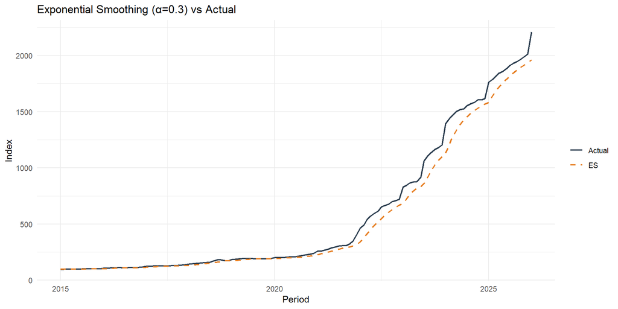

```r
p_es <- ggplot(df_long %>% mutate(es=es_fitted), aes(x=period)) +
  geom_line(aes(y=cci, color="Actual"), linewidth=0.8) +
  geom_line(aes(y=es,  color="ES"),    linewidth=0.8, linetype="dashed") +
  scale_color_manual(values=c("Actual"="#2C3E50","ES"="#E67E22")) +
  labs(title="Exponential Smoothing (α=0.3) vs Actual", x="Period", y="Index", color="") +
  theme_minimal()
print(p_es)
```

```r
ggsave("outputs/figures/exponential_smoothing_plot.png", p_es, width=10, height=5)
```

## 7.5 Trend-Adjusted Exponential Smoothing (Holt)

```r
holt_model  <- holt(ts_cci, alpha=0.3, beta=0.1, h=1)
holt_fitted <- as.numeric(fitted(holt_model))
holt_acc    <- calc_accuracy(as.numeric(ts_cci), holt_fitted)
holt_next   <- as.numeric(forecast(holt_model)$mean[1])
cat("Holt Feb 2026 forecast:", holt_next, "\n")
```

```
## Holt Feb 2026 forecast: 2132.481
```

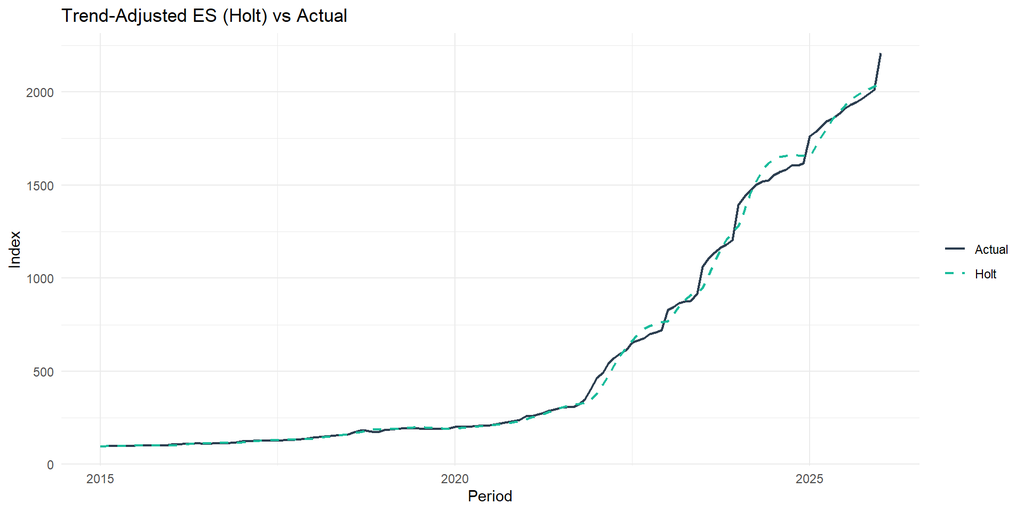

```r
p_holt <- ggplot(df_long %>% mutate(holt=holt_fitted), aes(x=period)) +
  geom_line(aes(y=cci,  color="Actual"), linewidth=0.8) +
  geom_line(aes(y=holt, color="Holt"),  linewidth=0.8, linetype="dashed") +
  scale_color_manual(values=c("Actual"="#2C3E50","Holt"="#1ABC9C")) +
  labs(title="Trend-Adjusted ES (Holt) vs Actual", x="Period", y="Index", color="") +
  theme_minimal()
print(p_holt)
```

```r
ggsave("outputs/figures/trend_adjusted_smoothing_plot.png", p_holt, width=10, height=5)
```

## 7.6 Linear Trend Projection

```r
df_long <- df_long %>% mutate(t = row_number())
lm_model  <- lm(cci ~ t, data=df_long)
lm_fitted <- fitted(lm_model)
lm_acc    <- calc_accuracy(df_long$cci, lm_fitted)
lm_next   <- predict(lm_model, newdata=data.frame(t=nrow(df_long)+1))
cat("Linear Trend Feb 2026 forecast:", lm_next, "\n")
```

```
## Linear Trend Feb 2026 forecast: 1524.209
```

```r
cat("Intercept:", coef(lm_model)[1], "  Slope:", coef(lm_model)[2], "\n")
```

```
## Intercept: -361.5815   Slope: 14.07306
```

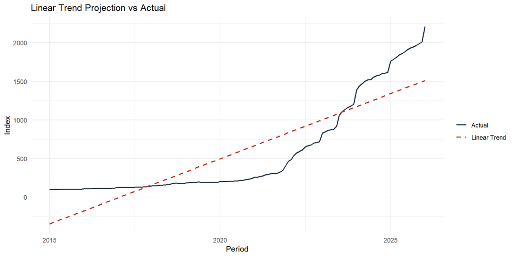

```r
p_lm <- ggplot(df_long, aes(x=period)) +
  geom_line(aes(y=cci,      color="Actual"),       linewidth=0.8) +
  geom_line(aes(y=lm_fitted,color="Linear Trend"), linewidth=0.8, linetype="dashed") +
  scale_color_manual(values=c("Actual"="#2C3E50","Linear Trend"="#C0392B")) +
  labs(title="Linear Trend Projection vs Actual", x="Period", y="Index", color="") +
  theme_minimal()
print(p_lm)
```

```r
ggsave("outputs/figures/trend_projection_plot.png", p_lm, width=10, height=5)
```

## 7.7 Seasonal Indices

```r
overall_mean <- mean(df_long$cci)
s_idx <- df_long %>%
  mutate(month = month(period)) %>%
  group_by(month) %>%
  summarise(s_index = mean(cci) / overall_mean) %>% ungroup()

df_long <- df_long %>%
  mutate(month = month(period)) %>%
  left_join(s_idx, by="month") %>%
  mutate(deseas = cci / s_index)

lm_deseas  <- lm(deseas ~ t, data=df_long)
df_long    <- df_long %>% mutate(si_fitted = fitted(lm_deseas) * s_index)
si_acc     <- calc_accuracy(df_long$cci, df_long$si_fitted)

s_feb      <- s_idx %>% filter(month==2) %>% pull(s_index)
t_next     <- nrow(df_long) + 1
si_next    <- (coef(lm_deseas)[1] + coef(lm_deseas)[2]*t_next) * s_feb
cat("Seasonal Indices Feb 2026 forecast:", si_next, "\n")
```

```
## Seasonal Indices Feb 2026 forecast: 1350.401
```

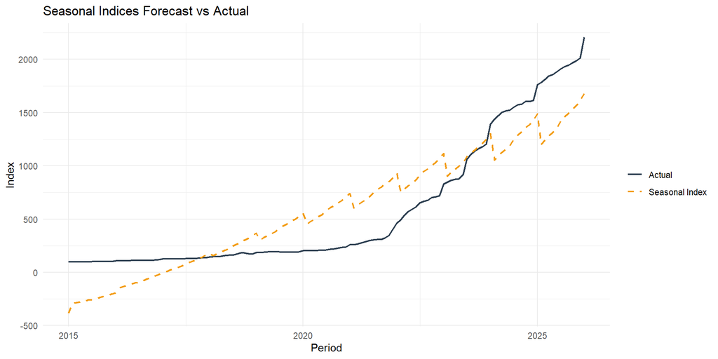

```r
p_si <- ggplot(df_long, aes(x=period)) +
  geom_line(aes(y=cci,       color="Actual"),          linewidth=0.8) +
  geom_line(aes(y=si_fitted, color="Seasonal Index"),  linewidth=0.8, linetype="dashed") +
  scale_color_manual(values=c("Actual"="#2C3E50","Seasonal Index"="#F39C12")) +
  labs(title="Seasonal Indices Forecast vs Actual", x="Period", y="Index", color="") +
  theme_minimal()
print(p_si)
```

```r
ggsave("outputs/figures/seasonal_indices_plot.png", p_si, width=10, height=5)
```

## 7.8 Additive Decomposition

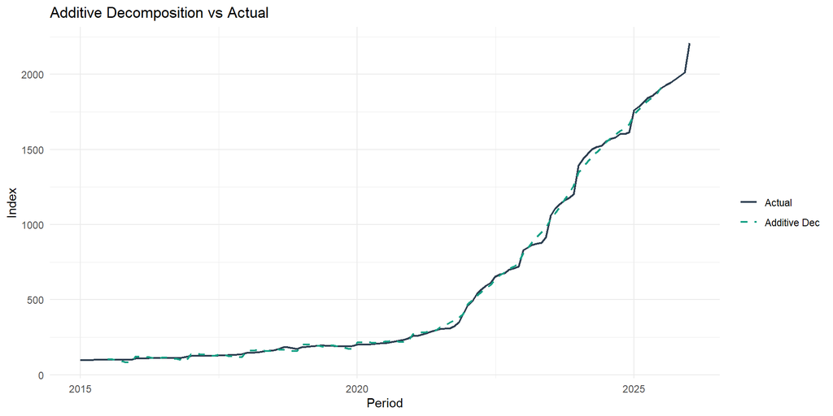

```r
decomp_add <- decompose(ts_cci, type="additive")
add_fitted <- as.numeric(ts_cci) - as.numeric(decomp_add$random)
valid_add  <- !is.na(as.numeric(decomp_add$random))
add_acc    <- calc_accuracy(as.numeric(ts_cci)[valid_add], add_fitted[valid_add])

p_add <- ggplot(df_long, aes(x=period)) +
  geom_line(aes(y=cci,        color="Actual"),     linewidth=0.8) +
  geom_line(aes(y=add_fitted, color="Additive Dec"), linewidth=0.8, linetype="dashed") +
  scale_color_manual(values=c("Actual"="#2C3E50","Additive Dec"="#16A085")) +
  labs(title="Additive Decomposition vs Actual", x="Period", y="Index", color="") +
  theme_minimal()
print(p_add)
```

```r
ggsave("outputs/figures/additive_decomposition_plot.png", p_add, width=10, height=5)
```

## 7.9 Multiplicative Decomposition

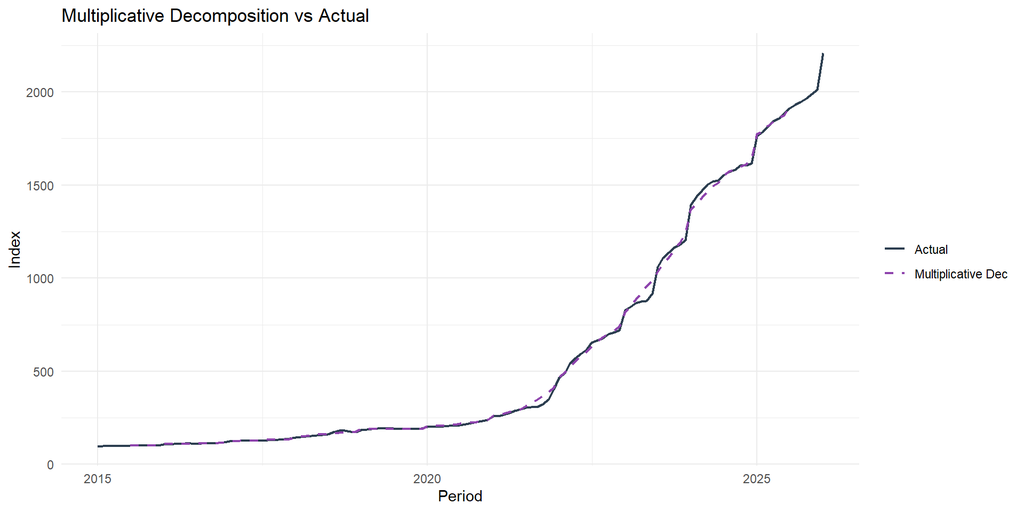

```r
decomp_mul <- decompose(ts_cci, type="multiplicative")
mul_fitted <- as.numeric(ts_cci) / as.numeric(decomp_mul$random)
valid_mul  <- !is.na(as.numeric(decomp_mul$random))
mul_acc    <- calc_accuracy(as.numeric(ts_cci)[valid_mul], mul_fitted[valid_mul])

p_mul <- ggplot(df_long, aes(x=period)) +
  geom_line(aes(y=cci,        color="Actual"),           linewidth=0.8) +
  geom_line(aes(y=mul_fitted, color="Multiplicative Dec"), linewidth=0.8, linetype="dashed") +
  scale_color_manual(values=c("Actual"="#2C3E50","Multiplicative Dec"="#8E44AD")) +
  labs(title="Multiplicative Decomposition vs Actual", x="Period", y="Index", color="") +
  theme_minimal()
print(p_mul)
```

```r
ggsave("outputs/figures/multiplicative_decomposition_plot.png", p_mul, width=10, height=5)
```

## 7.10 Regression with Trend and Seasonal Dummies

```r
df_long <- df_long %>% mutate(month_f = factor(month(period)))
reg_model  <- lm(cci ~ t + month_f, data=df_long)
reg_fitted <- fitted(reg_model)
reg_acc    <- calc_accuracy(df_long$cci, reg_fitted)
new_data   <- data.frame(t=nrow(df_long)+1, month_f=factor(2, levels=1:12))
reg_next   <- predict(reg_model, newdata=new_data)
cat("Regression Feb 2026 forecast:", reg_next, "\n")
```

```
## Regression Feb 2026 forecast: 1531.463
```

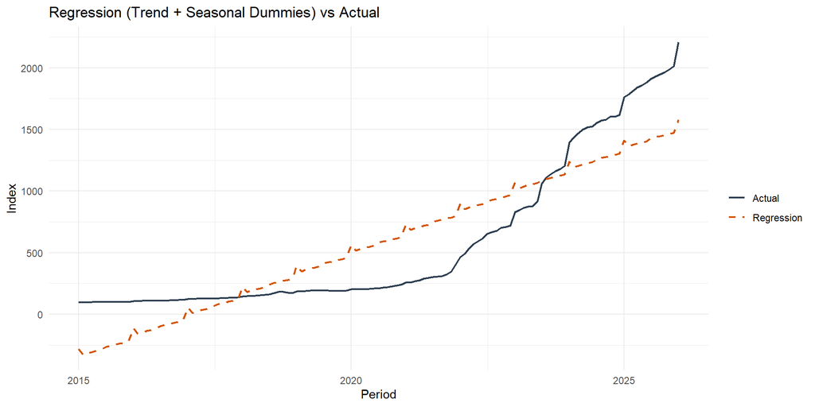

```r
p_reg <- ggplot(df_long, aes(x=period)) +
  geom_line(aes(y=cci,       color="Actual"),     linewidth=0.8) +
  geom_line(aes(y=reg_fitted,color="Regression"), linewidth=0.8, linetype="dashed") +
  scale_color_manual(values=c("Actual"="#2C3E50","Regression"="#D35400")) +
  labs(title="Regression (Trend + Seasonal Dummies) vs Actual", x="Period", y="Index", color="") +
  theme_minimal()
print(p_reg)
```

```r
ggsave("outputs/figures/regression_seasonal_dummy_plot.png", p_reg, width=10, height=5)
```

# 8 Accuracy Comparison

```r
results <- tibble(
  Method = c("Naïve","Moving Average (k=3)","Weighted MA",
             "Exp. Smoothing","Holt (Trend-Adj.)","Linear Trend",
             "Seasonal Indices","Additive Decomp.","Multiplicative Decomp.",
             "Regression (Trend+Seasonal)"),
  Bias = c(naive_acc$Bias, ma_acc$Bias, wma_acc$Bias, es_acc$Bias,
           holt_acc$Bias, lm_acc$Bias, si_acc$Bias, add_acc$Bias,
           mul_acc$Bias, reg_acc$Bias),
  MAD  = c(naive_acc$MAD,  ma_acc$MAD,  wma_acc$MAD,  es_acc$MAD,
           holt_acc$MAD,  lm_acc$MAD,  si_acc$MAD,  add_acc$MAD,
           mul_acc$MAD,  reg_acc$MAD),
  MSE  = c(naive_acc$MSE,  ma_acc$MSE,  wma_acc$MSE,  es_acc$MSE,
           holt_acc$MSE,  lm_acc$MSE,  si_acc$MSE,  add_acc$MSE,
           mul_acc$MSE,  reg_acc$MSE),
  MAPE = c(naive_acc$MAPE, ma_acc$MAPE, wma_acc$MAPE, es_acc$MAPE,
           holt_acc$MAPE, lm_acc$MAPE, si_acc$MAPE, add_acc$MAPE,
           mul_acc$MAPE, reg_acc$MAPE),
  RSFE = c(naive_acc$RSFE, ma_acc$RSFE, wma_acc$RSFE, es_acc$RSFE,
           holt_acc$RSFE, lm_acc$RSFE, si_acc$RSFE, add_acc$RSFE,
           mul_acc$RSFE, reg_acc$RSFE),
  TS   = c(naive_acc$TS,   ma_acc$TS,   wma_acc$TS,   es_acc$TS,
           holt_acc$TS,   lm_acc$TS,   si_acc$TS,   add_acc$TS,
           mul_acc$TS,   reg_acc$TS),
  Next_Forecast = c(naive_next, ma_next, wma_next, es_next, holt_next,
                    as.numeric(lm_next), as.numeric(si_next),
                    NA, NA, as.numeric(reg_next))
)

results %>%
  kable(digits=2, caption="Forecast Accuracy Comparison — All Methods") %>%
  kable_styling(bootstrap_options=c("striped","hover","condensed"))
```

Forecast Accuracy Comparison — All Methods

| Method | Bias | MAD | MSE | MAPE | RSFE | TS | Next_Forecast |
| --- | --- | --- | --- | --- | --- | --- | --- |
| Naïve | 16.01 | 16.27 | 1253.79 | 2.45 | 2113.11 | 129.87 | 2210.24 |
| Moving Average (k=3) | 30.91 | 31.21 | 2951.98 | 4.64 | 4018.52 | 128.77 | 2070.19 |
| Weighted MA | 26.03 | 26.32 | 2253.53 | 3.92 | 3384.27 | 128.58 | 2107.13 |
| Exp. Smoothing | 48.52 | 48.59 | 5960.01 | 6.89 | 6453.81 | 132.83 | 2034.73 |
| Holt (Trend-Adj.) | 2.79 | 20.56 | 1329.28 | 3.03 | 370.91 | 18.04 | 2132.48 |
| Linear Trend | 0.00 | 265.31 | 92076.66 | 107.24 | 0.00 | 0.00 | 1524.21 |
| Seasonal Indices | -2.48 | 261.67 | 92356.48 | 105.85 | -330.35 | -1.26 | 1350.40 |
| Additive Decomp. | -1.16 | 15.44 | 433.04 | 4.98 | -139.79 | -9.05 | NA |
| Multiplicative Decomp. | -1.60 | 8.97 | 267.66 | 1.90 | -193.91 | -21.62 | NA |
| Regression (Trend+Seasonal) | 0.00 | 265.79 | 91552.78 | 107.57 | 0.00 | 0.00 | 1531.46 |

```r
write.csv(results, "outputs/tables/accuracy_comparison.csv", row.names=FALSE)
```